# SSD

Shudong Sun

2024-05-16

# Introduction

SSD can determine the sample size for our experiment when we only have a few pilot data. Firstly, it can generate different synthetic training datasets and test datasets. Then it will calculate the corresponding different test classiﬁcation error/ARI/AMI or user self-defiend metric. The final step is to construct the plots in the terms of the sample size and the different metrics (test classiﬁcation error/ARI/AMI or user self-defiend metric). Users can determine the sample size by the above plots.

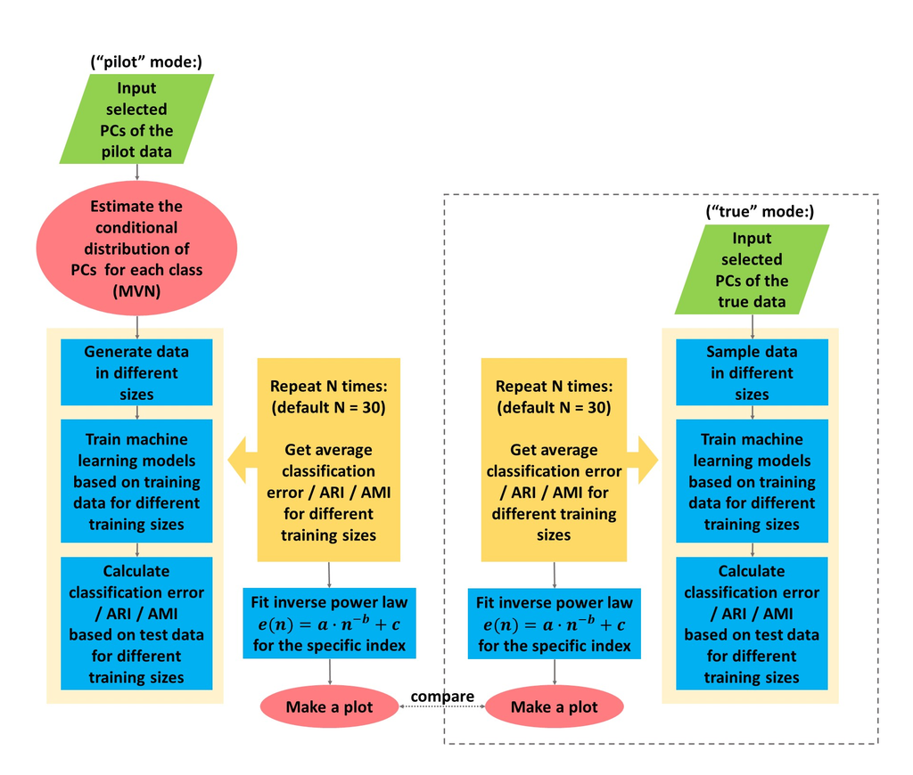

Workflow of the SSD package

# Preparations

Before we dive into the main task, we need to load the package and an example dataset for our task. The dataset we use is the **pbmc_68k** dataset from [10x Genomics](https://support.10xgenomics.com/single-cell-gene-expression/datasets).

We pre-processed the dataset: In this dataset, *phenoid* is the y label which has 10 classes. We sampled 15 observations from the original dataset for each class and assemble them as the pilot data. we normalize and scale the pilot data at first and then run principal component analysis (PCA) and keep 18 PCs according to *JackStrawPlot* and *ElbowPlot* mentioned in [Seurat - Guided Clustering Tutorial](https://satijalab.org/seurat/articles/pbmc3k_tutorial.html). The *JackStrawPlot* and *ElbowPlot* are shown below:

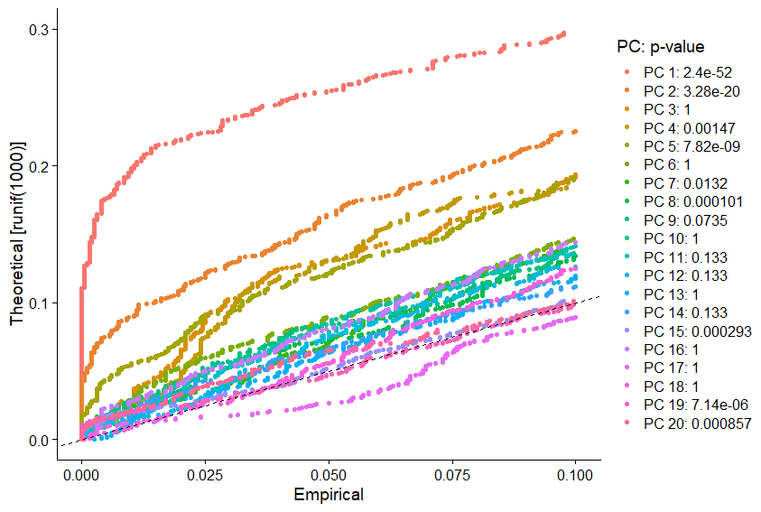

JackStrawPlot of the pilot data

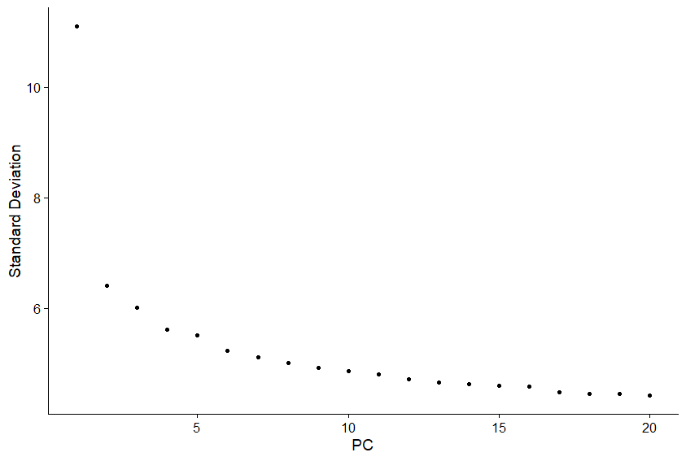

ElbowPlot of the pilot data

We put the pre-processed data into our package and we can load them directly.

```r
library(SSD)

# load data -----------------------------------------------------------------------------
pilot_data <- read.csv(system.file("extdata", "data_pbmc68k_pilot_18pc.csv", package = "SSD"),row.names=1)
print(table(pilot_data$phenoid))
```

```
#>
#>               CD14+_Monocyte                      CD19+_B
#>                           15                           15
#>              CD4+/CD25_T_Reg   CD4+/CD45RA+/CD25-_Naive_T
#>                           15                           15
#>          CD4+/CD45RO+_Memory               CD4+_T_Helper2
#>                           15                           15
#>                     CD56+_NK CD8+/CD45RA+_Naive_Cytotoxic
#>                           15                           15
#>             CD8+_Cytotoxic_T                    Dendritic
#>                           15                           15
```

# Task

## With pilot data, draw the plot and determine sample size using the built-in model

In the default setting, we use the built-in *random forest* to train the model. The `index` we use is Adjusted Rand Index (ARI). By default, the size of training data for each class is (30, 60, 90, 120, … , 540, 570, 600) and the size of test data for each class is 300.

```r
x_pilot = pilot_data[,-length(pilot_data)]
y_pilot = pilot_data[,length(pilot_data)]

result_pilot = ssd(x_pilot, y_pilot, index = "ARI")
```

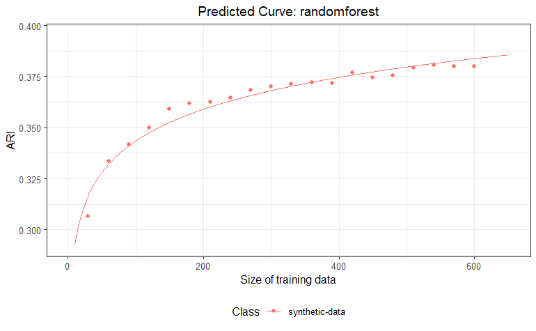

## With pilot data, draw the plot and determine sample size using the self-defined model

If you want to use the model defined by yourself. Then you need to write a “predict_model” function including your model. The function should take *train_data_x* and *train_data_y* as the first two inputs to train the model and then take *test_data_x* as the third input and return the predicted result of *test_data_x*. Then you could set `model` to *self* and set `func` to *predict_model*, and run the model using your self-defined function.

```r
library(e1071)

predict_model <- function(train_data_x, train_data_y, test_data_x){
    train_data = data.frame(train_data_x, as.factor(train_data_y))
    names(train_data)[length(train_data)] = "class"
    fit_svm<-svm(class~.,data=train_data,probability=TRUE)
    pred <- predict(fit_svm, test_data_x)
    return(pred)
}
```

```r
result_pilot_self = ssd(x_pilot, y_pilot, model="self", func=predict_model)
```

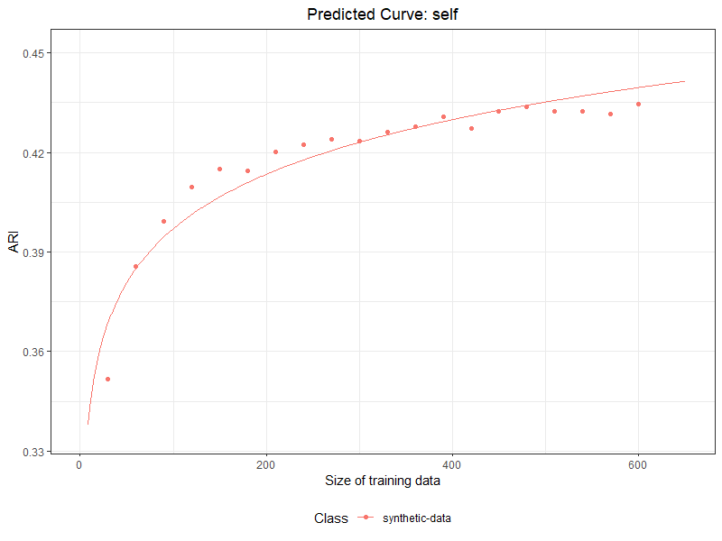

You could use the following code to check the function you defined. The result has to be the predicted value of *test_data_x*.

```r
train_data <- read.csv(system.file("extdata", "data_pbmc68k_train_23pc.csv", package = "SSD"),row.names=1)
test_data <- read.csv(system.file("extdata", "data_pbmc68k_test_23pc.csv", package = "SSD"),row.names=1)

num_class=10
n_train=60
n_test=100

for(i in 1:num_class){
  class_i_ids = which(train_data$phenoid == names(table(train_data$phenoid))[i])

  train_test_i_ids = sample(class_i_ids, (n_train+n_test))
  train_i_data = train_data[train_test_i_ids[1:n_train],]
  test_i_data = train_data[train_test_i_ids[(n_train+1):(n_train+n_test)],]

  if(i == 1){
    train_data_sample = train_i_data
    test_data_sample = test_i_data
  }else{
    train_data_sample = rbind(train_data_sample, train_i_data)
    test_data_sample = rbind(test_data_sample, test_i_data)
  }
}

train_data_x = train_data_sample[,-length(train_data_sample)]
train_data_y = train_data_sample$phenoid
test_data_x = test_data_sample[,-length(test_data_sample)]

result = predict_model(train_data_x, train_data_y, test_data_x)
```

## With pilot data, draw the plot and determine sample size using the self-defined index

If you want to use the index defined by yourself. Then you need to write a new function including your index. This function should be able to take prediction and true_label as the first two inputs to calculate the metric.

```r
classification_accuracy <- function(prediction, true_label){
    correct <- sum(true_label == prediction)
    acc <- correct/length(prediction)
    return(acc)
}
```

```r
result_accuracy = ssd(x_pilot, y_pilot, index="self", metric_func=classification_accuracy)
```

## With pilot data and large true data, draw the plot and compare the result

If we have large enough true data and we can compare the plot drawn based on pilot data and the plot drawn based on true data. For the original dataset, we split the it into training data and test data first, then we ran principal component analysis (PCA). We pre-processed the training dataset using the same stratigies and keep 23 PCs according to *JackStrawPlot* and *ElbowPlot* ,and then project the test set onto the reduced feature space obtained during the training.

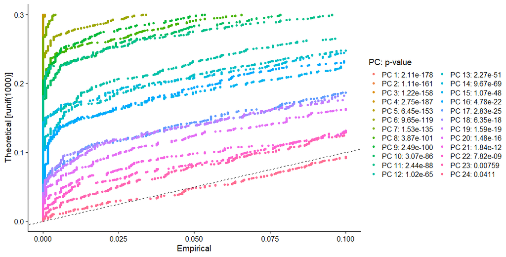

JackStrawPlot of the whole dataset

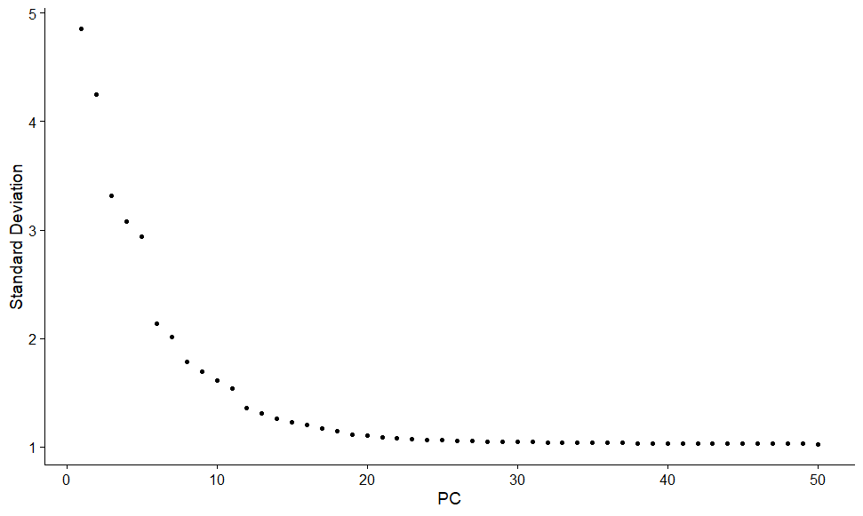

ElbowPlot of the whole dataset

To get the plot drawn based on true data, we could change `mode` to *true* and compare the results.

```r
# load large true data
train_data <- read.csv(system.file("extdata", "data_pbmc68k_train_23pc.csv", package = "SSD"),row.names=1)
test_data <- read.csv(system.file("extdata", "data_pbmc68k_test_23pc.csv", package = "SSD"),row.names=1)
print(table(train_data$phenoid))
```

```
#>
#>               CD14+_Monocyte                      CD19+_B
#>                         3717                         3206
#>              CD4+/CD25_T_Reg   CD4+/CD45RA+/CD25-_Naive_T
#>                         2712                         3026
#>          CD4+/CD45RO+_Memory               CD4+_T_Helper2
#>                         5759                        11345
#>                     CD56+_NK CD8+/CD45RA+_Naive_Cytotoxic
#>                        14012                        21875
#>             CD8+_Cytotoxic_T                    Dendritic
#>                         1765                          162
```

```r
print(table(test_data$phenoid))
```

```
#>
#>               CD14+_Monocyte                      CD19+_B
#>                          100                          100
#>              CD4+/CD25_T_Reg   CD4+/CD45RA+/CD25-_Naive_T
#>                          100                          100
#>          CD4+/CD45RO+_Memory               CD4+_T_Helper2
#>                          100                          100
#>                     CD56+_NK CD8+/CD45RA+_Naive_Cytotoxic
#>                          100                          100
#>             CD8+_Cytotoxic_T                    Dendritic
#>                          100                          100
```

```r
# prepare large true data
x_true_train = train_data[,-length(train_data)]
y_true_train = train_data[,length(train_data)]

x_true_test = test_data[,-length(test_data)]
y_true_test = test_data[,length(test_data)]

# run the model using the true data, index using 'ARI'
result_true_11 = ssd(x=x_true_train, y=y_true_train, model = "randomforest", index="ARI", n_train_list=seq(from=30, to=600,by=30),
                     mode="true", test_x=x_true_test, test_y=y_true_test, n_test=300)
```

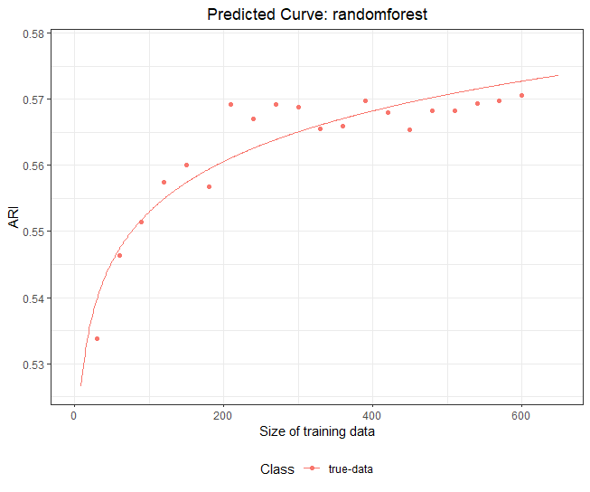

Furthermore, we incrementally added more data to the pilot dataset to simulate real-world data collection, as illustrated in the plots below. Specifically, we added 15 cells from each class to the initial pilot dataset (Pilot Data 1), resulting in Pilot Data 2 with 30 cells per class. We then added 30 cells from each class to Pilot Data 2, creating Pilot Data 3 with 60 cells per class. Finally, we added another 30 cells from each class to Pilot Data 3, resulting in Pilot Data 4 with 90 cells per class.

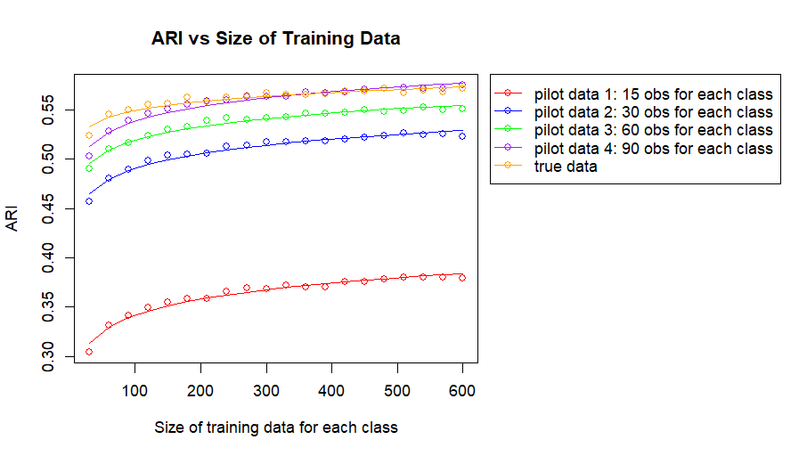

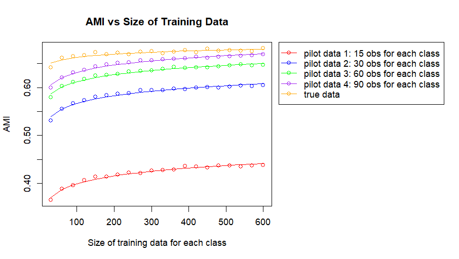

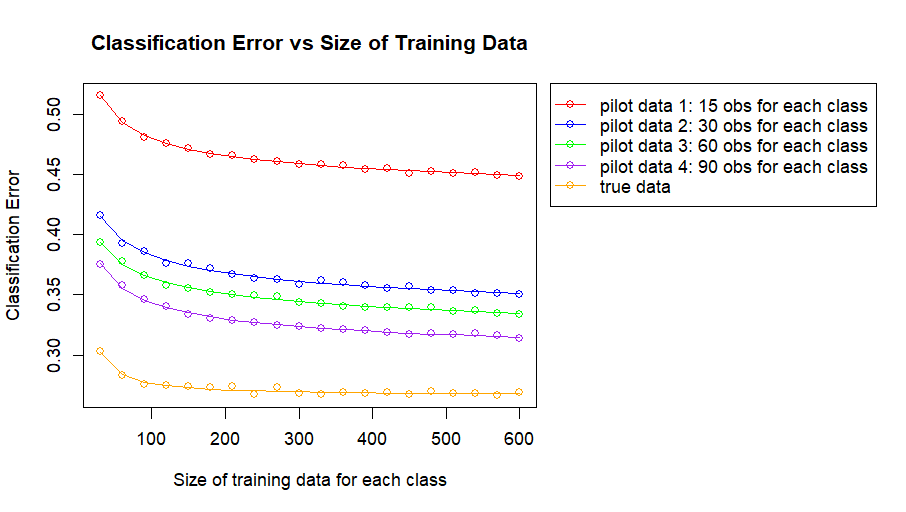

This process shows that as more data is collected, the synthetic learning curve increasingly approximates the true curve.

# Appendix: Code for Drawing the Comparison Plot

```r
pilot_data_15 <- read.csv("D:/OneDrive/OneDrive - University of Arizona/USC/RA/2020summer/multi-cell sample size/code/results_24_05_15/data_pbmc68k_pilot_15_18pc.csv",row.names=1)
print(table(pilot_data_15$phenoid))
x_pilot_15 = pilot_data_15[,-length(pilot_data_15)]
y_pilot_15 = pilot_data_15[,length(pilot_data_15)]

pilot_15_ARI = ssd(x_pilot_15, y_pilot_15, index = "ARI")
```

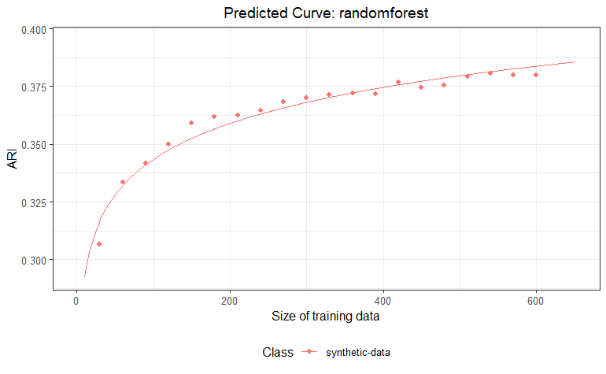

```r
pilot_data_30 <- read.csv("D:/OneDrive/OneDrive - University of Arizona/USC/RA/2020summer/multi-cell sample size/code/results_24_05_15/data_pbmc68k_pilot_30_18pc.csv",row.names=1)
print(table(pilot_data_30$phenoid))
x_pilot_30 = pilot_data_30[,-length(pilot_data_30)]
y_pilot_30 = pilot_data_30[,length(pilot_data_30)]

pilot_30_ARI = ssd(x_pilot_30, y_pilot_30, index = "ARI")
```

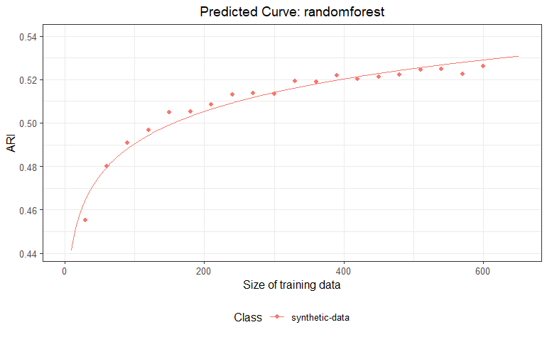

```r
pilot_data_60 <- read.csv("D:/OneDrive/OneDrive - University of Arizona/USC/RA/2020summer/multi-cell sample size/code/results_24_05_15/data_pbmc68k_pilot_60_22pc.csv",row.names=1)
print(table(pilot_data_60$phenoid))
x_pilot_60 = pilot_data_60[,-length(pilot_data_60)]
y_pilot_60 = pilot_data_60[,length(pilot_data_60)]

pilot_60_ARI = ssd(x_pilot_60, y_pilot_60, index = "ARI")
```

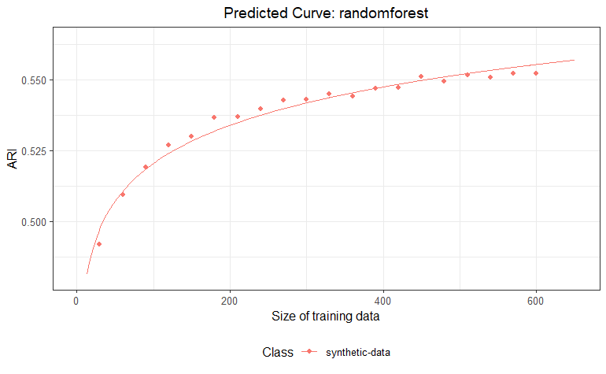

```r
pilot_data_90 <- read.csv("D:/OneDrive/OneDrive - University of Arizona/USC/RA/2020summer/multi-cell sample size/code/results_24_05_15/data_pbmc68k_pilot_90_22pc.csv",row.names=1)
print(table(pilot_data_90$phenoid))
x_pilot_90 = pilot_data_90[,-length(pilot_data_90)]
y_pilot_90 = pilot_data_90[,length(pilot_data_90)]

pilot_90_ARI = ssd(x_pilot_90, y_pilot_90, index = "ARI")
```

[output not shown]

```r
train_data <- read.csv(system.file("extdata", "data_pbmc68k_train_23pc.csv", package = "SSD"),row.names=1)
test_data <- read.csv(system.file("extdata", "data_pbmc68k_test_23pc.csv", package = "SSD"),row.names=1)
print(table(train_data$phenoid))
print(table(test_data$phenoid))

# prepare large true data
x_true_train = train_data[,-length(train_data)]
y_true_train = train_data[,length(train_data)]
table(train_data$phenoid)

x_true_test = test_data[,-length(test_data)]
y_true_test = test_data[,length(test_data)]
table(test_data$phenoid)


true_ARI = ssd(x=x_true_train, y=y_true_train, model = "randomforest", index="ARI", n_train_list=seq(from=30, to=600,by=30),
                     mode="true", test_x=x_true_test, test_y=y_true_test, n_test=300)
```

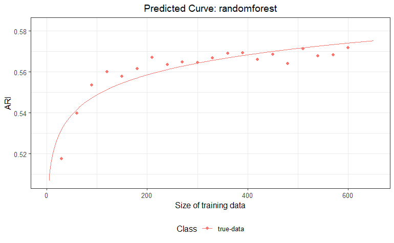

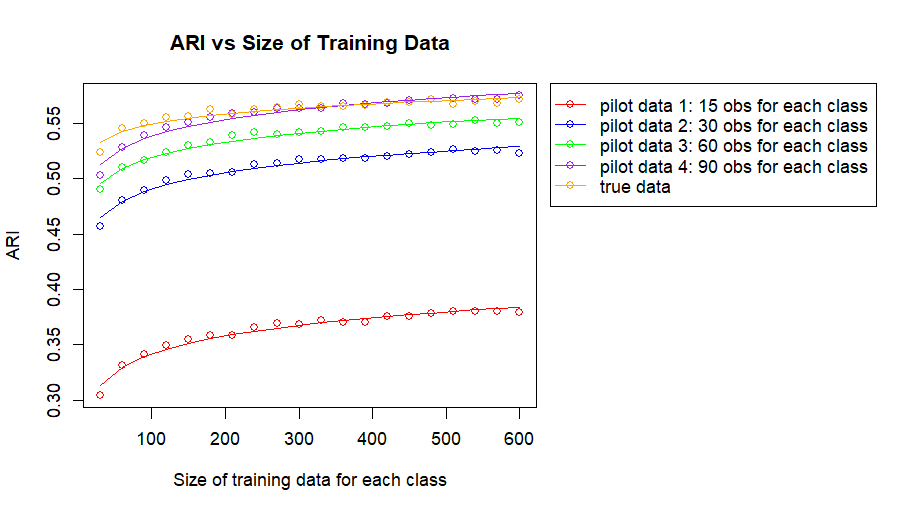

```r
# combine previous results
results_ARI <- rbind(pilot_15_ARI, pilot_30_ARI, pilot_60_ARI, pilot_90_ARI, true_ARI)

# Convert to matrix data
results_ARI <- as.matrix(results_ARI)

# Create x-axis
x <- seq(from = 30, to = 600, by = 30)

# Define the fitting function
fit_function <- function(x, a, b, c) {
  return(a * x^(-b) + c)
}

# Fit the data for each row
fits <- apply(results_ARI, 1, function(y) {
  nlsLM(y ~ fit_function(x, a, b, c), start = list(a = 0.5, b = 0.1, c = 0.1), control = nls.lm.control(maxiter = 1000))
})

# Get fitted values
fitted_values <- sapply(fits, function(fit) {
  predict(fit, list(x = x))
})

# Custom colors
colors <- c("red", "blue", "green", "purple", "orange")

# Adjust margins to place the legend
par(mar = c(5, 4, 4, 18) + 0.1)

legends <- c("pilot data 1: 15 obs for each class", "pilot data 2: 30 obs for each class",
             "pilot data 3: 60 obs for each class", "pilot data 4: 90 obs for each class",
             "true data")

# Plot original data and fitted curves
matplot(x, t(results_ARI), type = "p", pch = 1, col = colors, xlab = "Size of training data for each class", ylab = "ARI", main = "ARI vs Size of Training Data")
matlines(x, fitted_values, type = "l", lty = 1, col = colors)

# Add legend
legend("topright", inset = c(-0.75, 0), legend = legends, col = colors, pch = 1, lty = 1, xpd = TRUE)
```